# QTM 151 - Quiz 5

## Try to submit as an HTML file

Print your name below

```python
# Write your answer here

print("Daisy Cossio Garcia")
```

```
Daisy Cossio Garcia
```

This quiz is open book

- You can use the lecture notes
- You will get partial credit for attempting the questions
- To get full credit, the code should run as intended
- You should NOT communicate with other students

Print the following message:

"I will abide by Emory's code of conduct"

```python
# Write your answer here:
print("I will abide by Emory's code of conduct")
```

```
I will abide by Emory's code of conduct
```

Import the libraries "matplotlib.pyplot" and "pandas"

```python
# Write your answer here

import pandas as pd
import matplotlib.pyplot as plt
import matplotlib.dates as mdates
from datetime import date, time, datetime
```

In this quiz you will work with data on exchange rates,  
for the following currencies:

- 1 euro (EUR) to dollar (USD)
- 1 pound (GPB) to dollar (USD).

(a) Import and parse dates

- Import the dataset "currencies.csv"
- Parse the "date_string" column with `pd.to_datetime()`
- To get full points, set the "format" option using wildcards as in Lecture 21.

```python
# Write your own code

currencies = pd.read_csv("data_raw/currencies.csv")
currencies["date"] = pd.to_datetime(currencies["date_string"])

date1 = pd.to_datetime(currencies["date_string"], format = "%A, %b %d, %Y")
display(date1)
```

```
0      1999-01-04
1      1999-01-05
2      1999-01-06
3      1999-01-07
4      1999-01-08
          ...
6320   2023-03-27
6321   2023-03-28
6322   2023-03-29
6323   2023-03-30
6324   2023-03-31
Name: date_string, Length: 6325, dtype: datetime64[ns]
```

(b) Plot multiple time series

- Create a line plot plot which has the "gbp_to_usd" and "eur_to_usd" on the y-axis

and the date on the x-axis

- Label the x-axis, the y-axis, and the title
- Add a legend and set the names to "1 Euro to USD" and "1 GPB to USD"

Hint: See Lecture 22 for how to plot multiple columns  
Hint: Remember to include the legend names as a list `[...]`

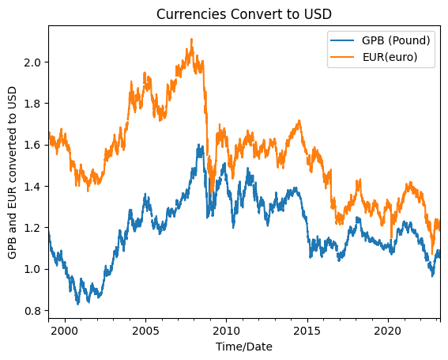

```python
# Write your own code

currencies["date"] = pd.to_datetime(currencies["date_string"])
currencies         = currencies.sort_values("date",ascending = True)

(currencies[["date","gbp_to_usd","eur_to_usd"]]
    .set_index("date").plot())
plt.xlabel("Time/Date")
plt.ylabel("GPB and EUR converted to USD")
plt.legend(["GPB (Pound)","EUR(euro)"])
plt.title("Currencies Convert to USD")
```

(c) Compute growth rates

- Calculate a new column "growth_euro" which computes the percentage daily

growth rate of "eur_to_usd".

Hint: Use `.diff()` and `.shift(1)` as in Lecture 22

```python
# Write your own code
currencies["diff_euro"] = currencies["eur_to_usd"].diff()
currencies["lag_euro"]    = currencies["eur_to_usd"].shift(1)
currencies["growth_euro"] = currencies["diff_euro"]* 100/currencies["lag_euro"]

display(currencies[["eur_to_usd","lag_euro","diff_euro","growth_euro"]])
```

|  | eur_to_usd | lag_euro | diff_euro | growth_euro |
| --- | --- | --- | --- | --- |
| 0 | 1.6581 | NaN | NaN | NaN |
| 1 | 1.6566 | 1.6581 | -0.0015 | -0.090465 |
| 2 | 1.6547 | 1.6566 | -0.0019 | -0.114693 |
| 3 | 1.6495 | 1.6547 | -0.0052 | -0.314256 |
| 4 | 1.6405 | 1.6495 | -0.0090 | -0.545620 |
| ... | ... | ... | ... | ... |
| 6320 | 1.2278 | 1.2225 | 0.0053 | 0.433538 |
| 6321 | 1.2341 | 1.2278 | 0.0063 | 0.513113 |
| 6322 | 1.2313 | 1.2341 | -0.0028 | -0.226886 |
| 6323 | 1.2368 | 1.2313 | 0.0055 | 0.446682 |
| 6324 | 1.2369 | 1.2368 | 0.0001 | 0.008085 |

6325 rows × 4 columns

(d) Flag subset of data and plot

- Create a boolean colum (True/False) "bool_cond" which checks whether

"growth_euro" had a value greater than 2 or less than -2

- Generate a line plot with the "growth_euro" series, label the axes and the title
- Use the command `plt.fill_between()` as in Lecture 22 to create a shaded region

for time periods where "bool_cond" is true.

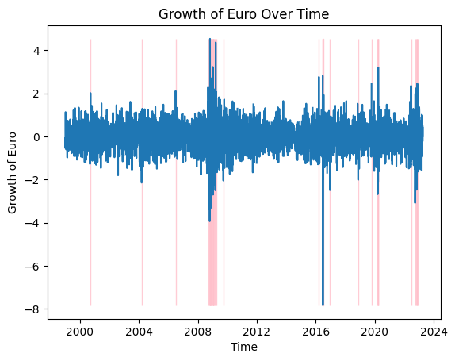

```python
# Write your own code

currencies["bool_cond1"] = currencies["growth_euro"] >2
currencies["bool_cond2"] = currencies["growth_euro"] < -2

plt.plot("date", "growth_euro", data = currencies)
plt.xlabel("Time")
plt.ylabel("Growth of Euro")
plt.title("Growth of Euro Over Time")

vec_y = currencies["growth_euro"]
plt.fill_between(x= currencies["date"],
                 y1 = vec_y.min(),
                 y2 = vec_y.max(),
                 where = currencies["bool_cond1"] | currencies["bool_cond2"],
                 alpha = 0.8,color = "pink")
plt.show()
```

(e) Aggregate dataset by time period

- Create an object "month_config" that uses `pd.Grouper()`, setting the key to

the column "date" and freq to "m" (month)

- Follow the instructions in Lecture 21 to compute an aggregate dataset

by month which computes the standard deviation of "eur_to_usd"

- Display the dataset

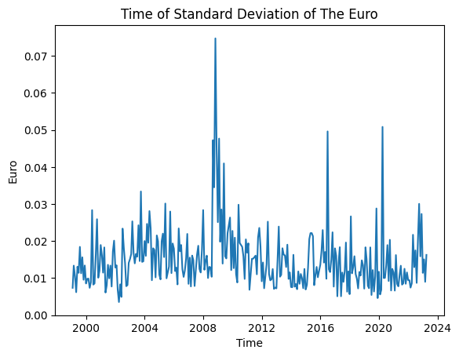

```python
# Write your own code

month_config = pd.Grouper(key='date', freq='m')
monthlydata = (currencies
               .groupby(month_config)
               .agg(euro_stf = ("eur_to_usd","std"))
               .reset_index())

plt.plot("date","euro_stf",
          data = monthlydata.sort_values("date",ascending = True))
plt.xlabel("Time")
plt.ylabel("Euro")
plt.title("Time of Standard Deviation of The Euro")
```

(f) Convert a dataset to long format

- Convert the currencies dataset to long format using the following inputs

```
var_name   = "type",
value_name = "exchange_rate",
id_vars    = "date",
value_vars = ["eur_to_usd","gbp_to_usd"]
```

- Display the dataset

Hint: See Lecture 22 for details on `pd.melt()`

```python
# Write your own code
currencies_long = pd.melt(currencies,
                         var_name   = "type",
                         value_name = "exchange_rate",
                         id_vars='date',
                         value_vars=['eur_to_usd','gbp_to_usd'])

display(currencies_long)
```

|  | date | type | exchange_rate |
| --- | --- | --- | --- |
| 0 | 1999-01-04 | eur_to_usd | 1.6581 |
| 1 | 1999-01-05 | eur_to_usd | 1.6566 |
| 2 | 1999-01-06 | eur_to_usd | 1.6547 |
| 3 | 1999-01-07 | eur_to_usd | 1.6495 |
| 4 | 1999-01-08 | eur_to_usd | 1.6405 |
| ... | ... | ... | ... |
| 12645 | 2023-03-27 | gbp_to_usd | 1.0789 |
| 12646 | 2023-03-28 | gbp_to_usd | 1.0844 |
| 12647 | 2023-03-29 | gbp_to_usd | 1.0826 |
| 12648 | 2023-03-30 | gbp_to_usd | 1.0899 |
| 12649 | 2023-03-31 | gbp_to_usd | 1.0872 |

12650 rows × 3 columns